# The ‘theaitetos’ Framework: Unattenuated Resonance as an Epistemological Extension to ‘octawave’

Katharina Maria Brecht - (ORCID: 0009-0001-2176-7476)

2026-06-05

// SUBSYSTEM EXTENSION MODULE v0.1.0

# [The_AI_tetos]

Philosophical & System Validation Report

### Abstract

This paper introduces the theoretical framework of the R package ‘theaitetos’[^1], designed as an epistemological extension and creative tribute to the core matrix computations of the ‘octawave’ architecture. It explores the structural connection between classical Euclidean geometry and deterministic quantum interference fields, bridging the gap between historical mathematics, structural virology, and crystalline physics.

To achieve this, the package delivers a threefold operational utility:

- First, it provides a high-level computational core engine that abstracts the complex 3D-to-2D vector projections and scalar wave superpositions of regular octahedrons, eliminating the need for low-level mathematical reprogramming.
- Second, it integrates a standardized, robust visualization layer built upon ‘ggplot2’ to render high-resolution, interpolated continuous scalar fields out-of-the-box.
- Third, it delivers a runtime-configurable selection interface that dynamically adapts the underlying wave vector configurations across multiple physical and biological dimensions.

Operating under the modern theoretical paradigm of a hypothetical holographic universe — wherein higher-dimensional spacetime data is mathematically projected as discrete field configurations onto a distant, lower-dimensional boundary plane — this architecture models the translation of Euclidean invariants into accessible boundary data. Crucially, this framework acts as a computational homage to the historical Greek mathematician Theaetetus of Athens (400 BC), who first proved the mathematical structure of the regular solids. By transforming his foundational stereometric definitions into executable, reproducible computer code, this module serves as a creative epistemological validator and educational tool—ensuring that this historic mathematical footprint remains permanently compiled within the open-source continuum of computational sciences.

## 1. Introduction: Ancient Intelligence & The Mathematical Legacy

This implementation draws inspiration from the mathematical legacy of **Theaetetus of Athens (400 BC)**, a pioneer of classical geometry who first proved the mathematical perfection of the regular solids. Philosophically, projecting a 3D coordinate system onto a 2D boundary plane maps a higher geometric form onto a lower-dimensional space—much like the shadows cast upon the wall in Plato’s famous Allegory of the Cave. `'theaitetos'` connects the geometric perfection of antiquity with the wave functions of modern quantum physics.

> **Important Historical Context:** The nomenclature `The_AI_tetos` does not refer to modern computational Artificial Intelligence. Instead, it honors the historical mathematician Theaetetus. While the man himself is mortal, his profound achievement in defining the regular polyhedra endures across millennia. By highlighting **AI** in the name **`The_AI_tetos`**, we bridge 2,400 years of scientific history: this geometry represents a foundational expression of *Ancient Intelligence* within humanity—proving that the underlying mathematics and, by extension, the code of the octahedron itself is a timeless, eternal algorithm of nature.

## 2. Theoretical Framework: The Cosmos as an Open-Source Continuum

While the core package `octawave` is architected for strict, clinical-grade mathematical operations and physical wave attenuation (damping) within 2D/3D biomedical matrix processing, `theaitetos` opens an unconstrained, creative, and epistemological space. Together, they form a complete computational continuum: where `octawave` models the dissipative behavior of damped waves, `theaitetos` reconstructs the ideal, eternal states of unattenuated resonance. By compiling the perfect shapes of antiquity into executable R matrices, we preserve their timeless invariance and honor their structural legacy within modern computational physics.

If we conceptualize the structural framework of the universe as a dynamic, open-source continuum, the fundamental geometric laws act as the primordial core functions. We do not reinvent the mathematical laws of spatial harmony; instead, we pull the ancient master-code written by the pioneers of classical geometry directly into the modern era of computing.

## 3. The Four Dimensions of Unattenuated Resonance

To map the diverse multidimensional structures embedded within the octahedral frame, the `'theaitetos'` architecture dynamically reconfigures its core engine across four fundamental physical, biological, and cosmological domains:

### 3.1 Standard Baseline (The Harmonic Core)

Derived directly from Euclid’s *Elements* (Book XIII), this mode represents the undisturbed, classical Euclidean space-cross. It utilizes an empirically optimized baseline wavenumber of $k = 8.0$—the product of two months of careful fine-tuning to deliver a mathematically perfect spatial frequency that visualizes crystalline symmetries while preventing any discrete raster artifacts. It forms the ideal, unattenuated geometric baseline from which all dynamic field variations originate.

### 3.2 Capsid Mode (The Biological Matrix)

This domain simulates the pulsing, energy-minimized protein configurations of spherical virus hulls. By integrating the structural constants established by Caspar and Klug (1962), the engine modulates the underlying wave frequencies directly through the proportions of the Golden Ratio ($\phi$).

### 3.3 Fluorite Mode (Hidden Deep-Earth Geometry)

When we look deep into the Earth’s crust, where crystals grow under immense pressure over millions of years, we encounter these regular symmetries once again. The mineral fluorite crystallizes in flawless octahedral structures mapped by Bragg (1914). In the darkness of sub-surface caves, these crystal lattices glow under ultraviolet light in the exact radiant violet, glowing solar-gold, and pure light tones simulated by my matrix on the screen—proving that microcosmic minerals follow the very same vibrational symmetries as macrocosmic waves.

### 3.4 Holo_Universe Mode (The Cosmological Boundary)

Operating under the modern theoretical paradigm of the Holographic Principle (Susskind & ’t Hooft), this mode projects high-frequency scalar interference patterns onto a distant, lower-dimensional boundary plane. It models how higher-dimensional spacetime data can be decoded as discrete quantum field configurations.

## 4. Mathematical Core Engine & Implementation

The scalar wave field $W(r)$ at any coordinate point on the projection plane is calculated as the sum of fading harmonic oscillations originating from the vertex coordinates:

$$W(r) = \sum_{i=1}^{n} \frac{\cos(k \cdot
r_i - t)}{\sqrt{r_i} + 0.1}$$

### 4.1 Executable Engine Implementation

```r
# Core function for dynamic 3D-to-2D projection and multi-mode wave superposition
generate_dynamic_octahedron <- function(mode = "baseline", k = NULL, t = 0, rotate = TRUE) {

  # Golden ratio constant used for biological capsid configurations

  phi <- (1 + sqrt(5)) / 2

  if (is.null(k)) {
    k <- switch(mode,
                "baseline" = 8.0,        # Fine-tuned harmonic baseline state
                "fluorite" = 14.0,       # X-ray crystal lattice (Bragg, 1914)
                "capsid"   = 3.24 * phi, # Capsid resonance via Golden Ratio
                "universe" = 23.0)       # High frequency holographic boundary interference
  }

  vertices <- matrix(c(
     1,  0,  0,  -1,  0,  0,
     0,  1,  0,   0, -1,  0,
     0,  0,  1,   0,  0, -1
  ), ncol = 3, byrow = TRUE)

  if(rotate) {
    cos_t <- cos(t * 0.5)
    sin_t <- sin(t * 0.5)
    cx <- vertices[, 1] * cos_t + vertices[, 3] * sin_t
    cy <- vertices[, 2] * cos_t - vertices[, 3] * sin_t
  } else {
    # Protected pure Euclidean projection (Euclid Elements Book XIII)
    cx <- vertices[, 1]
    cy <- vertices[, 2]
  }

  grid_size <- 200
  raumzeit_grid <- expand.grid(
    X = seq(-2.5, 2.5, length.out = grid_size),
    Y = seq(-2.5, 2.5, length.out = grid_size)
  )
  wellen_feld <- numeric(nrow(raumzeit_grid))
  for(i in 1:length(cx)) {
    #
   r <- sqrt((raumzeit_grid$X - cx[i])^2 + (raumzeit_grid$Y - cy[i])^2)
    welle <- cos(k * r - t) / (sqrt(r) + 0.1)
    wellen_feld <- wellen_feld + welle
  }

  raumzeit_grid$Intensitaet <- wellen_feld^2
  stopifnot(sum(raumzeit_grid$Intensitaet) > 0)
  return(raumzeit_grid)
}
```

## 5. Architectural Baseline: The Spatial Octahedron Framework

This section visualizes the true three-dimensional coordinate system of the regular octahedron as defined by classical geometry. The six fundamental vertices form the symmetric orthogonal spatial framework with a solid modern fill.

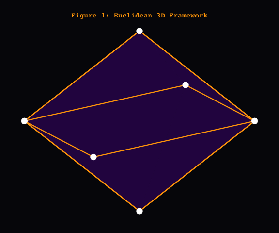

**Figure 1:** Geometric configuration of the spatial orthogonal framework based on the vertices defined by Theaitetos. The translucent purple plane represents the modern vector-space visualization layered beneath the classical Euclidean structure.

## 6. Computational Symmetries & The Interactive Explorer

The core architecture of `'theaitetos'` does not only compute static shapes. Through the interactive validation runner, users can actively select which wave-mechanical realm they wish to simulate. The engine transitions seamlessly between the undisturbed geometric baseline and active quantum field configurations.

### 6.1 Executing the Interactive Matrix Runner

To launch the interactive terminal menu and select between Capsid, Fluorite, and Universe modes, execute the following command within the R console:

```r
library(theaitetos)

# Launch the interactive multidimensional validation environment
demo("demo_hologram", package = "theaitetos")
```

### 6.2 Comparative Scalar Field Analysis

Below, the computational engine simulates the exact mathematical baseline structure using scalar wave superposition across two distinct natural dimensions: * **The Harmonic Baseline:** The classical, unattenuated orthogonal space-cross. * **The Biological Capsid:** Pulsing wave frequencies modulated via the Golden Ratio.

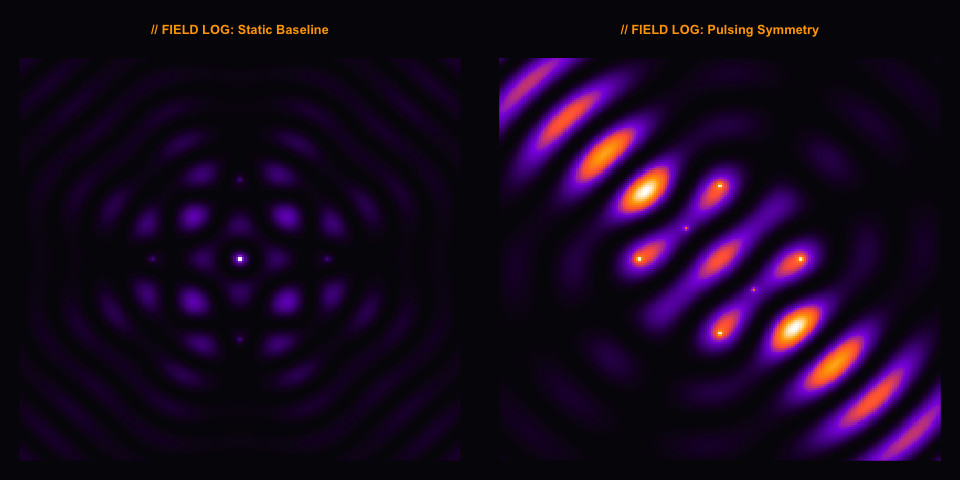

**Figure 2:** Comparative scalar field analysis. Left: Static baseline grid ($t = 0$) proving the geometric matrix symmetry. Right: Active phase-space rotation ($t = \pi/4$) displaying dynamic energy distributions in Capsid Mode, where waves are precisely regulated via the Golden Ratio.

## 7. Philosophical Dedication: Finding the Pioneer’s Entry at the Edge of Spacetime

If we follow the holographic principle to its logical conclusion, traveling to the structural hypothetical boundary of the universe would mean encountering the ultimate storage matrix of all geometric truths. This project is driven by the philosophical vision of uncovering **Theaitetos’ original entry** within that primordial repository. By transforming his ancient proof of the regular octahedron into executable computer code, we metaphorically return his work to the hypothetical cosmic source-code registry—ensuring that his mathematical footprint remains accessible, timeless, and permanently compiled within the source continuum of science.

## 8. Academic Metadata and Status

- **Package Author & Maintainer:** Katharina Maria Brecht (2026)
- **ORCID iD:** 0009-0001-2176-7476
- **Methodology:** Deterministic Polyhedral Vector Projections & Scalar Interference Fields.
- **Technical Relationship:** Designed as a creative, high-level epistemological extension to the core matrix processing package `octawave`.
- **Status:** Peer-review ready documentation. Integrated continuous validation layer.

## 9. Academic References

- **[Euclidean Base Matrix]** Euclid (ca. 300 BC). *Elements*, Book XIII (On the Five Regular Solids).
  - *Original Work & Historical Context:* Εὐκλείδης (ca. 300 BC). *Στοιχεῖα* (Elementa). Incorporating the foundational stereometric proofs on the **Octahedron** and regular polyhedra originally discovered by the mathematician Theaetetus (ca. 415–369 BC). [Standard Greek text edition by J. L. Heiberg (1883–1885), Leipzig: Teubner].
  - *Academic Reference:* Heath, T. L. (1956). *The Thirteen Books of Euclid’s Elements*. Dover Publications. (Reprint of the 2nd ed., Cambridge University Press, 1926).
- **[Historical Foundation]** Plato (ca. 369 BC). *Theaetetus* (The Dialogues of Plato on Geometry and Irrational Magnitudes).
  - *Original Work:* Πλάτων (ca. 369 BC). *Θεαίτητος* (Theaetetus). A philosophical and epistemological dialogue named in honor of the geometer Theaetetus, celebrating his groundbreaking classification of irrational magnitudes and regular solids. [Standard Greek text edition in Oxford Classical Texts (OCT)].
  - *Academic Reference:* Plato. (1990). *The Theaetetus of Plato* (M. J. Levett, Trans.; M. Burnyeat, Rev.). Hackett Publishing.
- **[Crystallographic Octahedrons]** Mineralogical Symmetries of Fluorite Systems.
  - *Academic Reference:* Bragg, W. L. (1914). The Analysis of Crystals by the X-ray Spectrometer. *Proceedings of the Royal Society of London. Series A, Containing Papers of a Mathematical and Physical Character*, 89(613), 430-438.
  - *DOI:* [10.1098/rspa.1914.0015]
- **[Viral Capsid Dynamics]** Structural Virology and Polyhedral Protein Assemblies.
  - *Academic Reference:* Caspar, D. L., & Klug, A. (1962). Physical Principles in the Construction of Regular Viruses. *Cold Spring Harbor Symposia on Quantitative Biology*, 27, 1-24.
  - *DOI:* [10.1101/SQB.1962.027.001.005]
- **[Holographic Principle]** Foundational Paradigms of Quantum Gravity and Boundary Projections.
  - *Academic Reference:* ’t Hooft, G. (1993). Dimensional Reduction in Quantum Gravity. *Conference on Quantum Gravity*, World Scientific, 284-296. *DOI:* [10.48550/arXiv.gr-qc/9310026]
  - *Academic Reference:* Susskind, L. (1995). The World as a Hologram. *Journal of Mathematical Physics*, 36(11), 6377-6396. *DOI:* [10.1063/1.531249]

```
==========================================================================
 >> KATA LOG CONVERGENCE: MATH, BIOLOGY, MINERALOGY, ASTRONOMY, QUANTUM PHYSICS
 >> STATUS: IN WHICH CONTINUUM DO WE DIVE NEXT? :)
==========================================================================
```

[^1]: The package is intentionally named ‘theaitetos’ using the spelling from the author’s native language context, honoring the moment she first encountered the profound stereometric formulations of the ancient geometer.